# NYPD Shooting Incident Data (Historic) Analysis

Juan Felipe Maldonado

2025-09-23

## Introduction

This report explores and analyses the *NYPD Shooting Incident Data (Historic)* dataset sourced from DATA.GOV. The dataset includes information about the time, location, race, gender, age and outcome of shooting incidents in New York.

The focus of this report will lay on analyzing the number of shooting incident victims per incident and patterns in victims over time. The report will answer:

- How many victims are there per shooting incident?
- What patterns are there on the number of victims over time?

Troughout the report there are also followup questions to promote further analysis of this rich dataset.

## Loading Tidyverse library

```r
library(tidyverse)
library(lubridate)
library(hms)
library(knitr)
library(ggplot2)
```

## Importing and showing a sample of NYPD shooting incident data

```r
shooting_data <- read.csv("https://data.cityofnewyork.us/api/views/833y-fsy8/rows.csv")
head(shooting_data)
```

```
##   INCIDENT_KEY OCCUR_DATE OCCUR_TIME     BORO LOC_OF_OCCUR_DESC PRECINCT
## 1    231974218 08/09/2021   01:06:00    BRONX                         40
## 2    177934247 04/07/2018   19:48:00 BROOKLYN                         79
## 3    255028563 12/02/2022   22:57:00    BRONX           OUTSIDE       47
## 4     25384540 11/19/2006   01:50:00 BROOKLYN                         66
## 5     72616285 05/09/2010   01:58:00    BRONX                         46
## 6     85875439 07/22/2012   21:35:00    BRONX                         42
##   JURISDICTION_CODE LOC_CLASSFCTN_DESC             LOCATION_DESC
## 1                 0
## 2                 0
## 3                 0             STREET            GROCERY/BODEGA
## 4                 0                                    PVT HOUSE
## 5                 0                      MULTI DWELL - APT BUILD
## 6                 2                    MULTI DWELL - PUBLIC HOUS
##   STATISTICAL_MURDER_FLAG PERP_AGE_GROUP PERP_SEX      PERP_RACE VIC_AGE_GROUP
```

[output cut: 20 more lines]

The sample is analyzed using the data dictionary in: https://data.cityofnewyork.us/api/views/833y-fsy8/files/e4e3d86c-348f-4a16-a17f-19480c089429?download=true&filename=NYPD_Shootings_Incident_Level_Data_Footnotes.pdf

Information in (X_COORD_CD,Y_COORD_CD),(Latitude,Longitude) and Lon_Lat is redundant.

INCIDENT_KEY is not distinct. Incidents with multiple victims can have multiple entries.

## Data summary

```r
summary(shooting_data)
```

```
##   INCIDENT_KEY        OCCUR_DATE         OCCUR_TIME            BORO
##  Min.   :  9953245   Length:29744       Length:29744       Length:29744
##  1st Qu.: 67321140   Class :character   Class :character   Class :character
##  Median :109291972   Mode  :character   Mode  :character   Mode  :character
##  Mean   :133850951
##  3rd Qu.:214741917
##  Max.   :299462478
##
##  LOC_OF_OCCUR_DESC     PRECINCT      JURISDICTION_CODE LOC_CLASSFCTN_DESC
##  Length:29744       Min.   :  1.00   Min.   :0.0000    Length:29744
##  Class :character   1st Qu.: 44.00   1st Qu.:0.0000    Class :character
##  Mode  :character   Median : 67.00   Median :0.0000    Mode  :character
##                     Mean   : 65.23   Mean   :0.3181
##                     3rd Qu.: 81.00   3rd Qu.:0.0000
##                     Max.   :123.00   Max.   :2.0000
##                                      NA's   :2
##  LOCATION_DESC      STATISTICAL_MURDER_FLAG PERP_AGE_GROUP
##  Length:29744       Length:29744            Length:29744
##  Class :character   Class :character        Class :character
##  Mode  :character   Mode  :character        Mode  :character
##
##
##
##
##    PERP_SEX          PERP_RACE         VIC_AGE_GROUP        VIC_SEX
##  Length:29744       Length:29744       Length:29744       Length:29744
##  Class :character   Class :character   Class :character   Class :character
##  Mode  :character   Mode  :character   Mode  :character   Mode  :character
##
##
##
##
##    VIC_RACE          X_COORD_CD         Y_COORD_CD           Latitude
##  Length:29744       Length:29744       Length:29744       Min.   :40.51
##  Class :character   Class :character   Class :character   1st Qu.:40.67
##  Mode  :character   Mode  :character   Mode  :character   Median :40.70
##                                                           Mean   :40.74
##                                                           3rd Qu.:40.83
##                                                           Max.   :40.91
##                                                           NA's   :97
##    Longitude        Lon_Lat
##  Min.   :-74.25   Length:29744
##  1st Qu.:-73.94   Class :character
##  Median :-73.91   Mode  :character
##  Mean   :-73.91
##  3rd Qu.:-73.88
##  Max.   :-73.70
##  NA's   :97
```

Data types need to be adjusted.

## Exploring categorical data

```r
shooting_data %>% count(BORO) %>% arrange(n)
```

```
##            BORO     n
## 1 STATEN ISLAND   822
## 2     MANHATTAN  3977
## 3        QUEENS  4426
## 4         BRONX  8834
## 5      BROOKLYN 11685
```

```r
shooting_data %>% count(LOC_OF_OCCUR_DESC) %>% arrange(n)
```

```
##   LOC_OF_OCCUR_DESC     n
## 1            INSIDE   682
## 2           OUTSIDE  3466
## 3                   25596
```

```r
shooting_data %>% count(PRECINCT) %>% arrange(n)
```

```
##    PRECINCT    n
## 1        22    1
## 2        17   10
## 3       111   13
## 4       112   23
## 5        19   27
## 6         1   29
## 7         6   29
## 8       123   33
## 9        68   36
## 10       18   48
## 11       20   50
## 12       66   53
## 13       13   64
## 14      122   64
```

[output cut: 63 more lines]

```r
shooting_data %>% count(JURISDICTION_CODE) %>% arrange(n)
```

```
##   JURISDICTION_CODE     n
## 1                NA     2
## 2                 1   109
## 3                 2  4676
## 4                 0 24957
```

```r
shooting_data %>% count(LOC_CLASSFCTN_DESC) %>% arrange(n)
```

```
##    LOC_CLASSFCTN_DESC     n
## 1              (null)     7
## 2         PARKING LOT    16
## 3             VEHICLE    33
## 4             TRANSIT    52
## 5          PLAYGROUND    67
## 6               OTHER    74
## 7          COMMERCIAL   276
## 8            DWELLING   341
## 9             HOUSING   643
## 10             STREET  2639
## 11                    25596
```

```r
shooting_data %>% count(LOCATION_DESC) %>% arrange(n)
```

```
##                LOCATION_DESC     n
## 1                        ATM     1
## 2                 CHECK CASH     1
## 3             DOCTOR/DENTIST     1
## 4               LOAN COMPANY     1
## 5                     SCHOOL     1
## 6           STORAGE FACILITY     1
## 7           PHOTO/COPY STORE     2
## 8                       BANK     3
## 9       GYM/FITNESS FACILITY     4
## 10         FACTORY/WAREHOUSE     8
## 11               VIDEO STORE     8
## 12               CHAIN STORE     9
## 13                DEPT STORE     9
## 14               CANDY STORE    10
```

[output cut: 27 more lines]

```r
shooting_data %>% count(STATISTICAL_MURDER_FLAG) %>% arrange(n)
```

```
##   STATISTICAL_MURDER_FLAG     n
## 1                    true  5765
## 2                   false 23979
```

```r
shooting_data %>% count(PERP_AGE_GROUP) %>% arrange(n)
```

```
##    PERP_AGE_GROUP    n
## 1            1020    1
## 2            1028    1
## 3            2021    1
## 4             224    1
## 5             940    1
## 6             65+   67
## 7           45-64  775
## 8          (null) 1628
## 9             <18 1805
## 10        UNKNOWN 3148
## 11          25-44 6342
## 12          18-24 6630
## 13                9344
```

```r
shooting_data %>% count(PERP_SEX) %>% arrange(n)
```

```
##   PERP_SEX     n
## 1        F   461
## 2        U  1500
## 3   (null)  1628
## 4           9310
## 5        M 16845
```

```r
shooting_data %>% count(PERP_RACE) %>% arrange(n)
```

```
##                        PERP_RACE     n
## 1 AMERICAN INDIAN/ALASKAN NATIVE     2
## 2       ASIAN / PACIFIC ISLANDER   184
## 3                          WHITE   305
## 4                 BLACK HISPANIC  1487
## 5                         (null)  1628
## 6                        UNKNOWN  1838
## 7                 WHITE HISPANIC  2667
## 8                                 9310
## 9                          BLACK 12323
```

```r
shooting_data %>% count(VIC_AGE_GROUP) %>% arrange(n)
```

```
##   VIC_AGE_GROUP     n
## 1          1022     1
## 2       UNKNOWN    68
## 3           65+   236
## 4         45-64  2118
## 5           <18  3081
## 6         18-24 10677
## 7         25-44 13563
```

```r
shooting_data %>% count(VIC_SEX) %>% arrange(n)
```

```
##   VIC_SEX     n
## 1       U    12
## 2       F  2891
## 3       M 26841
```

```r
shooting_data %>% count(VIC_RACE) %>% arrange(n)
```

```
##                         VIC_RACE     n
## 1 AMERICAN INDIAN/ALASKAN NATIVE    13
## 2                        UNKNOWN    72
## 3       ASIAN / PACIFIC ISLANDER   478
## 4                          WHITE   741
## 5                 BLACK HISPANIC  2930
## 6                 WHITE HISPANIC  4511
## 7                          BLACK 20999
```

Grouping the variables by percentage of entries with unknown value:

- No unknown: BORO, PRECINCT, STATISTICAL_MURDER_FLAG
- Less than 50 % unknown: JURISDICTION_CODE, PERP_AGE_GROUP, PERP_SEX, PERP_RACE, VIC_AGE_GROUP, VIC_SEX, VIC_RACE
- 50% or more unknown: LOC_OF_OCCUR_DESC, LOC_CLASSFCTN_DESC, LOCATION_DESC

LOCATION_DESC has many distinct values and unknowns

PERP_AGE_GROUP, PERP_SEX, PERP_RACE use multiple categories for unknown

PERP_AGE_GROUP and VIC_AGE_GROUP include values outside allowed categories

## Dropping columns of little value to analysis

```r
shooting_data <- shooting_data %>% select(-c(LOCATION_DESC, X_COORD_CD, Y_COORD_CD, Lon_Lat))
```

## Setting all values outside of allowed categories to UNKNOWN (including missing values)

```r
shooting_data <- shooting_data %>% mutate(LOC_OF_OCCUR_DESC = if_else(LOC_OF_OCCUR_DESC %in% c("INSIDE", "OUTSIDE"), LOC_OF_OCCUR_DESC, "UNKNOWN")) %>% mutate(JURISDICTION_CODE = if_else(JURISDICTION_CODE %in% c(0, 1, 2, 3), as.character(JURISDICTION_CODE), "UNKNOWN")) %>% mutate(LOC_CLASSFCTN_DESC = if_else(LOC_CLASSFCTN_DESC %in% c("PARKING LOT", "VEHICLE", "TRANSIT", "PLAYGROUND", "OTHER", "COMMERCIAL", "DWELLING", "HOUSING", "STREET"), LOC_CLASSFCTN_DESC, "UNKNOWN")) %>% mutate(PERP_AGE_GROUP = if_else(PERP_AGE_GROUP %in% c("<18", "18-24", "25-44", "45-64", "65+"), PERP_AGE_GROUP, "UNKNOWN")) %>% mutate(PERP_SEX = if_else(PERP_SEX %in% c("F", "M"), PERP_SEX, "UNKNOWN")) %>% mutate(PERP_RACE = if_else(PERP_RACE %in% c("AMERICAN INDIAN/ALASKAN NATIVE", "ASIAN / PACIFIC ISLANDER", "WHITE", "BLACK HISPANIC","WHITE HISPANIC","BLACK"), PERP_RACE, "UNKNOWN")) %>% mutate(VIC_AGE_GROUP = if_else(VIC_AGE_GROUP %in% c("<18", "18-24", "25-44", "45-64", "65+"), VIC_AGE_GROUP, "UNKNOWN"))
```

## Setting correct data types

```r
shooting_data <- shooting_data %>% mutate(INCIDENT_KEY = as_factor(INCIDENT_KEY)) %>% mutate(OCCUR_DATE = mdy(OCCUR_DATE)) %>% mutate(OCCUR_TIME = as_hms(OCCUR_TIME)) %>% mutate(BORO = as_factor(BORO)) %>% mutate(LOC_OF_OCCUR_DESC = as_factor(LOC_OF_OCCUR_DESC)) %>% mutate(PRECINCT = as_factor(PRECINCT)) %>% mutate(JURISDICTION_CODE = as_factor(JURISDICTION_CODE)) %>% mutate(LOC_CLASSFCTN_DESC = as_factor(LOC_CLASSFCTN_DESC)) %>% mutate(STATISTICAL_MURDER_FLAG = (STATISTICAL_MURDER_FLAG == "true")) %>% mutate(PERP_AGE_GROUP = as_factor(PERP_AGE_GROUP)) %>% mutate(PERP_SEX = as_factor(PERP_SEX)) %>% mutate(PERP_RACE = as_factor(PERP_RACE)) %>% mutate(VIC_AGE_GROUP = as_factor(VIC_AGE_GROUP)) %>% mutate(VIC_SEX = as_factor(VIC_SEX)) %>% mutate(VIC_RACE = as_factor(VIC_RACE))
```

## Summary of tidied data

```r
summary(shooting_data)
```

```
##     INCIDENT_KEY     OCCUR_DATE           OCCUR_TIME
##  282117921:   20   Min.   :2006-01-01   Min.   :00:00:00.000000
##  173354054:   18   1st Qu.:2009-10-29   1st Qu.:03:30:45.000000
##  263503175:   16   Median :2014-03-25   Median :15:15:00.000000
##  23749375 :   12   Mean   :2014-10-31   Mean   :12:46:10.874798
##  24717013 :   12   3rd Qu.:2020-06-29   3rd Qu.:20:44:00.000000
##  33478089 :   12   Max.   :2024-12-31   Max.   :23:59:00.000000
##  (Other)  :29654
##             BORO       LOC_OF_OCCUR_DESC    PRECINCT     JURISDICTION_CODE
##  BRONX        : 8834   UNKNOWN:25596     75     : 1680   0      :24957
##  BROOKLYN     :11685   OUTSIDE: 3466     73     : 1561   2      : 4676
##  MANHATTAN    : 3977   INSIDE :  682     67     : 1288   1      :  109
##  QUEENS       : 4426                     44     : 1159   UNKNOWN:    2
##  STATEN ISLAND:  822                     79     : 1073
##                                          47     : 1048
##                                          (Other):21935
##   LOC_CLASSFCTN_DESC STATISTICAL_MURDER_FLAG PERP_AGE_GROUP     PERP_SEX
##  UNKNOWN   :25603    Mode :logical           UNKNOWN:14125   UNKNOWN:12438
##  STREET    : 2639    FALSE:23979             25-44  : 6342   M      :16845
##  HOUSING   :  643    TRUE :5765              18-24  : 6630   F      :  461
##  DWELLING  :  341                            <18    : 1805
##  COMMERCIAL:  276                            45-64  :  775
##  OTHER     :   74                            65+    :   67
##  (Other)   :  168
##                           PERP_RACE     VIC_AGE_GROUP   VIC_SEX
##  UNKNOWN                       :12776   18-24  :10677   M:26841
##  WHITE HISPANIC                : 2667   25-44  :13563   F: 2891
##  BLACK                         :12323   <18    : 3081   U:   12
##  BLACK HISPANIC                : 1487   45-64  : 2118
##  ASIAN / PACIFIC ISLANDER      :  184   65+    :  236
##  WHITE                         :  305   UNKNOWN:   69
##  AMERICAN INDIAN/ALASKAN NATIVE:    2
##                            VIC_RACE        Latitude       Longitude
##  BLACK                         :20999   Min.   :40.51   Min.   :-74.25
##  WHITE HISPANIC                : 4511   1st Qu.:40.67   1st Qu.:-73.94
##  BLACK HISPANIC                : 2930   Median :40.70   Median :-73.91
##  ASIAN / PACIFIC ISLANDER      :  478   Mean   :40.74   Mean   :-73.91
##  WHITE                         :  741   3rd Qu.:40.83   3rd Qu.:-73.88
##  UNKNOWN                       :   72   Max.   :40.91   Max.   :-73.70
##  AMERICAN INDIAN/ALASKAN NATIVE:   13   NA's   :97      NA's   :97
```

UNKOWN values will be handled by dropping rows or columns depending on the analysis to be performed.

## Analyzing number of victims per incident

```r
victims_per_incident <- shooting_data %>% count(INCIDENT_KEY,name = "Victims") %>% count(Victims,name = "Incidents")
total_incidents <- sum(victims_per_incident$Incidents)
victims_per_incident <- victims_per_incident %>% mutate(Percentage = (Incidents*100)/total_incidents)
kable(victims_per_incident)
```

| Victims | Incidents | Percentage |
| --- | --- | --- |
| 1 | 19450 | 83.4835608 |
| 2 | 2731 | 11.7220362 |
| 3 | 334 | 1.4335995 |
| 4 | 578 | 2.4808996 |
| 5 | 10 | 0.0429221 |
| 6 | 102 | 0.4378058 |
| 7 | 2 | 0.0085844 |
| 8 | 64 | 0.2747017 |
| 9 | 2 | 0.0085844 |
| 10 | 3 | 0.0128766 |
| 12 | 19 | 0.0815521 |
| 16 | 1 | 0.0042922 |
| 18 | 1 | 0.0042922 |
| 20 | 1 | 0.0042922 |

The table shows most incidents recorded involve only one victim, and more than 90% percent of all incidents involve two or less victims.

Additional questions for further analysis:

- Why are there so many incidents involving exactly 6, 8 or 12 victims, compared to other incidents with 5 or more victims?

# Analyzing number of victims over time

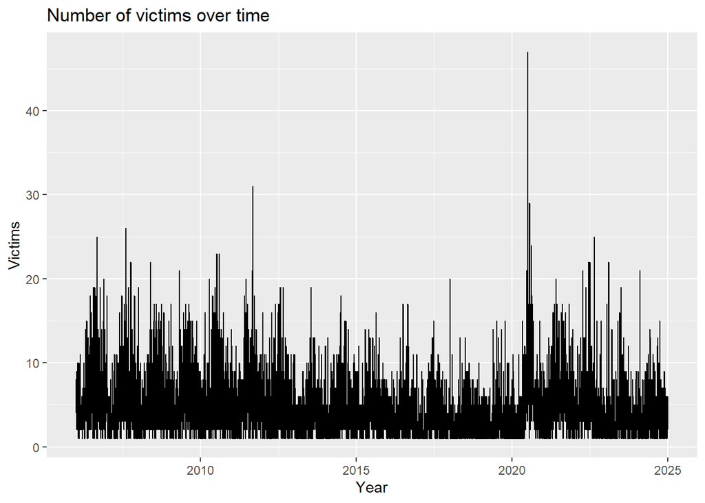

```r
victims_time <- shooting_data %>% count(OCCUR_DATE)
victims_time %>% ggplot(aes(x = .[[1]], y = .[[2]])) + geom_line() + ggtitle("Number of victims over time") + ylab("Victims") + xlab("Year")
```

A day after 2020 stands out for having many more incidents than any other day. What day was it? How many victims at that date?

```r
day_most_victims <- victims_time %>% slice_max(order_by = n)
cat("Day with most victims was", format(day_most_victims %>% getElement("OCCUR_DATE"), "%Y-%m-%d"), "with", day_most_victims %>% getElement("n"), "victims.")
```

```
## Day with most victims was 2020-07-05 with 47 victims.
```

Additional questions for further analysis:

- Why where there so many victims July 5th, 2020?
- How many incidents where involved?

Lead: https://www.cbsnews.com/newyork/news/new-york-city-shootings-sunday-nypd/

# Modeling number of victims over time

The graph of victims over time shows a vaguely periodic behavior. By modeling the victims over time as a sum of periodic sinusoids it’s possible to gain insights in to its periodic behavior. The model is constructed using the discrete Fourier transform of the data. Frequencies with a period shorter than a month are filtered out to simplify the model and filter out noise.

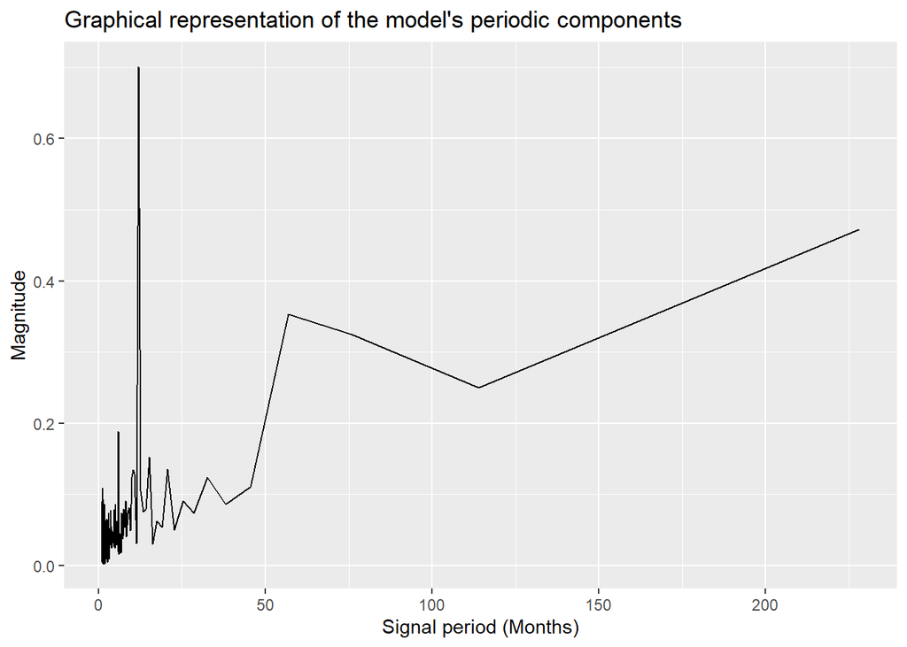

```r
# Ensure there is a row for every day
victims_all_days <- left_join(tibble(OCCUR_DATE = seq(from = min(shooting_data$OCCUR_DATE), to = max(shooting_data$OCCUR_DATE), by = "day")), victims_time, by="OCCUR_DATE") %>% replace(is.na(.), 0)
# Remove last sample if number of samples is even to only deal with odd FFT
samples <- nrow(victims_all_days)
if (samples %% 2 == 0) {victims_all_days <- victims_all_days %>% filter(row_number() < n())}
samples <- nrow(victims_all_days)
# Determine number of samples to filter lowest frequencies with a minimum period of a month
keep_n_frecuencies <- ceiling(samples/30.436875)
# Compute FFT
ftt_result <- tibble(fft(victims_all_days$n))
colnames(ftt_result) <- c("fft_res")
# Filter lowest frequencies with a minimum period of a month
filtered_fft <- ftt_result %>% mutate(fft_res = if_else(between(row_number(),keep_n_frecuencies + 2, samples - keep_n_frecuencies), 0, fft_res))

plot_data_filtered_fft <- filtered_fft %>% slice_head(n = keep_n_frecuencies + 1) %>% filter(row_number() > 1) %>% mutate(period_months = samples/(row_number()*30.436875)) %>% mutate(mag = Mod(fft_res)/samples)

plot_data_filtered_fft %>% ggplot(aes(x = period_months, y = mag)) + geom_line() + xlab("Signal period (Months)") + ylab("Magnitude") + ggtitle("Graphical representation of the model's periodic components")
```

```r
peak_signal_period <- plot_data_filtered_fft %>% slice_max(order_by = mag) %>% getElement("period_months")
cat("Peak signal with period of ", peak_signal_period, "months")
```

```
## Peak signal with period of  11.99895 months
```

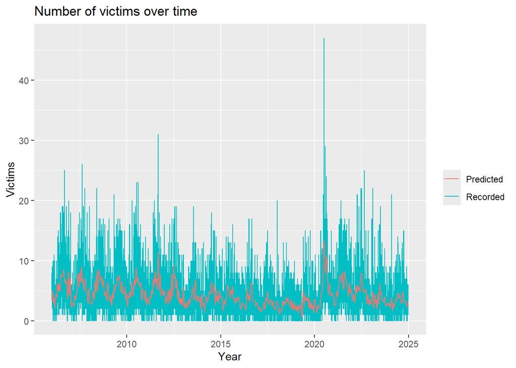

```r
victims_all_days <- victims_all_days %>% mutate(prediction = Re(fft(filtered_fft %>% getElement("fft_res"), inverse = TRUE))/samples)
colnames(victims_all_days) <- c("date","recorded_victims","predicted_victims")
victims_all_days %>% ggplot() + geom_line(aes(x = date, y = recorded_victims, color = "Recorded")) + geom_line(aes(x = date, y = predicted_victims, color = "Predicted")) + xlab("Year") + ylab("Victims") + labs(color = "") + ggtitle("Number of victims over time")
```

As shown by the graph comparing the recorded data to the model prediction, the model does a good job of conveying the periodic nature of the data. It does not do a good job of predicting the day to day number of victims as all periodic trends with a period of less than a month have been filtered out.

It is relevant that, as of September 2025, the model has a peak frequency component at 12 months. This yearly periodic behavior is further explored by analyzing the average number of victims per month of the year.

# Analyzing average number of victims by month of the year

```r
mon <- interval(min(shooting_data$OCCUR_DATE),max(shooting_data$OCCUR_DATE)) %/% months(1)
victims_mon <- shooting_data %>% count(month(OCCUR_DATE),name = "Victims") %>% mutate(Victims = Victims/mon)
colnames(victims_mon) <- c("Month of the year","Average number of victims")
kable(victims_mon)
```

| Month of the year | Average number of victims |
| --- | --- |
| 1 | 8.330397 |
| 2 | 6.753304 |
| 3 | 8.246696 |
| 4 | 9.471366 |
| 5 | 12.312775 |
| 6 | 13.616740 |
| 7 | 15.475771 |
| 8 | 14.766520 |
| 9 | 12.370044 |
| 10 | 10.938326 |
| 11 | 9.233480 |
| 12 | 9.515418 |

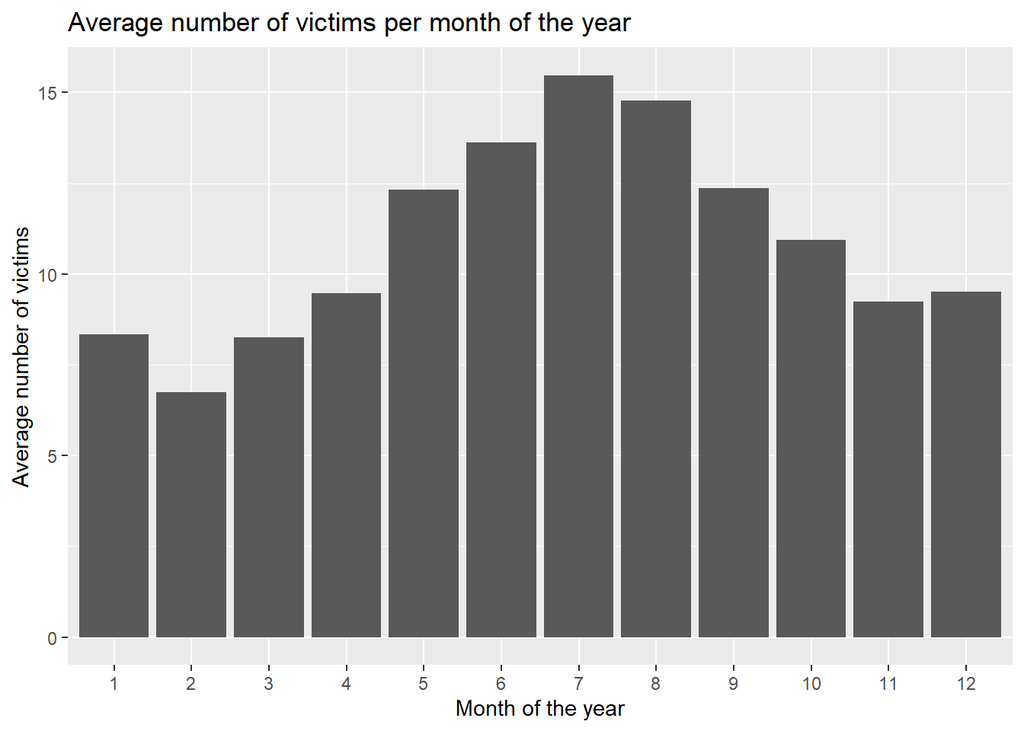

```r
victims_mon %>% ggplot(aes(x = .[[1]], y = .[[2]])) + geom_bar(stat = "identity") + ggtitle("Average number of victims per month of the year") + scale_x_discrete(name ="Month of the year", limits=1:12) + ylab("Average number of victims")
```

A roughly sinusoidal behavior is observed on the number of victims per month every year as predicted by the model. This periodic trend peaks in July and achieves its minimum in February.

Additional questions for further analysis:

- Is there a reason behind this periodic trend?
- Can other periodic trends be uncovered at high magnitude frequency signals of the model?

# Analyzing average number of victims by time of day

Because the model aggregated the data by day and filtered out trends with a period of less than a month, it could not uncover trends on the number of victims according to the time of day. To understand the hours of least and most victims on average the data is aggregated by hour of the day and graphed.

```r
# Obtains the total number of days spanned by the data
d <- as.integer(max(shooting_data$OCCUR_DATE)-min(shooting_data$OCCUR_DATE))
victims_hour <- shooting_data %>% count(hour(OCCUR_TIME),name = "Victims") %>% mutate(Victims = Victims/d)
colnames(victims_hour) <- c("Hour of the day","Average number of victims")
kable(victims_hour)
```

| Hour of the day | Average number of victims |
| --- | --- |
| 0 | 0.3367920 |
| 1 | 0.3196426 |
| 2 | 0.2768410 |
| 3 | 0.2488831 |
| 4 | 0.2216458 |
| 5 | 0.1109670 |
| 6 | 0.0590863 |
| 7 | 0.0366047 |
| 8 | 0.0386223 |
| 9 | 0.0366047 |
| 10 | 0.0482778 |
| 11 | 0.0625450 |
| 12 | 0.0807033 |
| 13 | 0.0926646 |
| 14 | 0.1282606 |
| 15 | 0.1465629 |
| 16 | 0.1665946 |
| 17 | 0.1690445 |
| 18 | 0.2020464 |
| 19 | 0.2333189 |
| 20 | 0.2658885 |
| 21 | 0.3108517 |
| 22 | 0.3383773 |
| 23 | 0.3556708 |

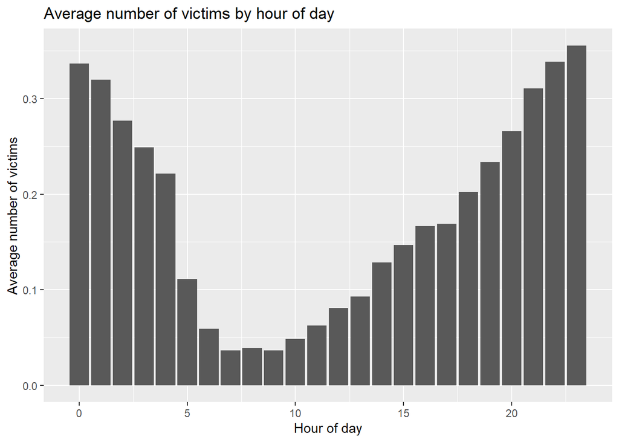

```r
victims_hour %>% ggplot(aes(x = .[[1]], y = .[[2]])) + geom_bar(stat = "identity") + ggtitle("Average number of victims by hour of day") + xlab("Hour of day") + ylab("Average number of victims")
```

Additional questions for further analysis:

- Why are there the least victims on average from 7 am to 10 am? Is it related to the fact people are getting ready and commuting to work?
- Why are there the most victims on average around midnight?
- The average number of victims seems to increase with the number of hours a person working a 9 to 5 job has been awake. Does tiredness increase the chance of a shooting incident?

# Analyze incident location

Location data is unrelated to the analysis so far, but it is plotted to encourage further analysis and show there is lots of analysis that can still be done with the remaining tidied variables.

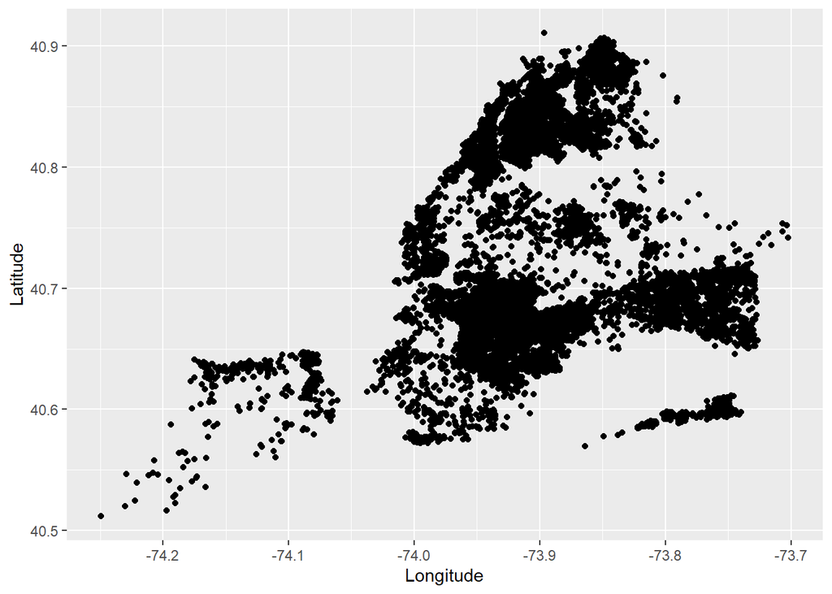

```r
shooting_data %>% ggplot(aes(x = Longitude, y = Latitude)) + geom_point()
```

Questions for further analysis:

- Is there a trend on how the incident locations are grouped?
- How do incident locations relate to other variables like time of the incident, age, race or gender?

# Bias Identification

This report dealt mainly with patterns over time. I am biased to believe patterns will repeat in periods of time I am familiar with like years, months, days or hours. This could be true regarding shooting incidents, as human behavior is probably influenced by those periods of time. But there could be other relevant factors in shooting incidents that are not influenced by human defined time periods. This bias was mitigated by using a mathematical model, and not only intuition, to uncover a strong yearly trend in the average number of victims per month.

I am also biased to believe most crime happens at night because, where I live, leaving home late at night is perceived as dangerous. The results of analyzing the average number of victims by time of day supports my bias. Considering the data was only averaged by hour of the day, there is little chance for me to introduce my bias in the analysis. Still, it could be further mitigated by having my work peer reviewed and performing additional analysis, but this is beyond the scope of this report.

# Conclusion

There is a lot of analysis potential in the NYPD Shooting Incident Data (Historic) database. The analysis in this report concludes that most shooting incidents in New York have only one victim. It was also noticed that the number of victims tends to vary periodically on a yearly basis, with the most victims in July and the least in February. Analysis of the average number of victims by time of day shows there are the least victims on average from 7 am to 10 am and the most around midnight. Finally, followup questions where formulated to encourage further analysis of the data beyond the scope of this report.